# Running RStudio on Hyak using On-Demand feature

see also: https://hyak.uw.edu/docs/ood/start

**Pro at RStudio but would benefit from more resources? It is easier than ever to launch at RStudio Instance on Hyak.**

## Access Dashboard

Go to https://ondemand.hyak.uw.edu/pun/sys/dashboard/

[figure not shown]

Click on Interactive Apps

[figure not shown]

## Selecting Resources

Decide on what specific resources are available and needed.

You will be then be asked for information on resources you will ask for.

[figure not shown]

If you this is the first experience with Klone you it might be good to get familar with what resources are available to you.

For this you can login to Klone at command line from this webpage by clicking on `>_Klone Login` and entering your credentials. From there you can run command `hyakalloc` to see what resources you have access to.

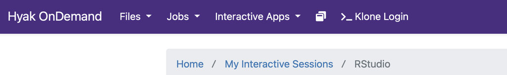

```
Last login: Thu May  1 10:23:40 2025 from 10.64.64.9
(base) [sr320@klone-login03 ~]$ hyakalloc
       Account resources available to user: sr320
╭─────────┬──────────────┬──────┬────────┬──────┬───────╮
│ Account │    Partition │ CPUs │ Memory │ GPUs │       │
├─────────┼──────────────┼──────┼────────┼──────┼───────┤
│   coenv │      compute │   40 │   175G │    0 │ TOTAL │
│         │              │   25 │   138G │    0 │ USED  │
│         │              │   15 │    37G │    0 │ FREE  │
├─────────┼──────────────┼──────┼────────┼──────┼───────┤
│   coenv │       cpu-g2 │  736 │  5714G │    0 │ TOTAL │
│         │              │  592 │  3220G │    0 │ USED  │
│         │              │  144 │  2494G │    0 │ FREE  │
├─────────┼──────────────┼──────┼────────┼──────┼───────┤
│   srlab │ cpu-g2-mem2x │   32 │   490G │    0 │ TOTAL │
│         │              │    4 │    45G │    0 │ USED  │
│         │              │   28 │   445G │    0 │ FREE  │
╰─────────┴──────────────┴──────┴────────┴──────┴───────╯
              Checkpoint Resources
╭─────────────────┬──────────────┬──────────────╮
│                 │         CPUs │         GPUs │
├─────────────────┼──────────────┼──────────────┤
│           Idle: │         4496 │          255 │
╰─────────────────┴──────────────┴──────────────╯
   Checkpoint is currently limited to 910 jobs
```

Based on the above information one might select

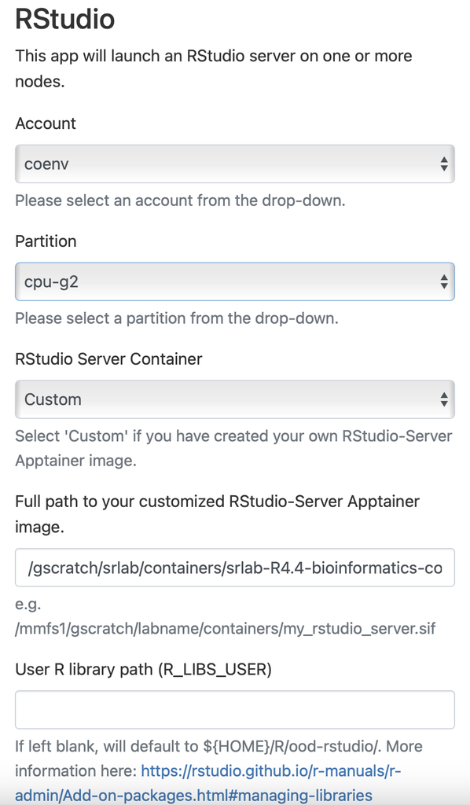

### Custom Container

One real value here is that customized Container files can you used.

See repo directory for list of files.

If you want to get started fast and are genomic inclined, feel free to use

`/gscratch/srlab/containers/srlab-R4.4-bioinformatics-container-a83e518.sif`

Which loads

[output not shown]

### Leveraging ckpt as resource

If you only need instance running < 5 hours one might say best practices would be to use `ckpt`. `ckpt` are unused resources by larger UW community thus not using your own group shared resources. However you will get kicked off at around 5 hours.

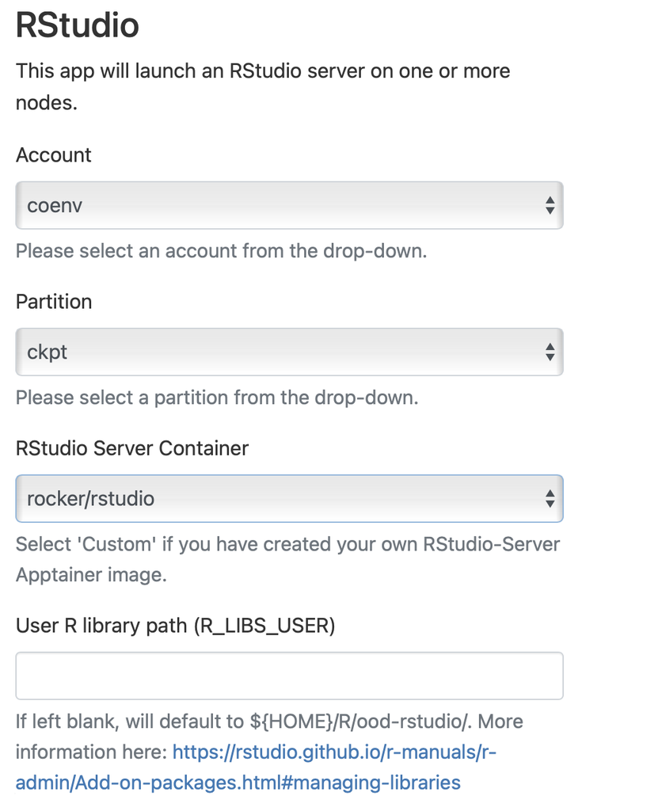

### Compute Parameters

You then need to select tasks, cpus, and memory

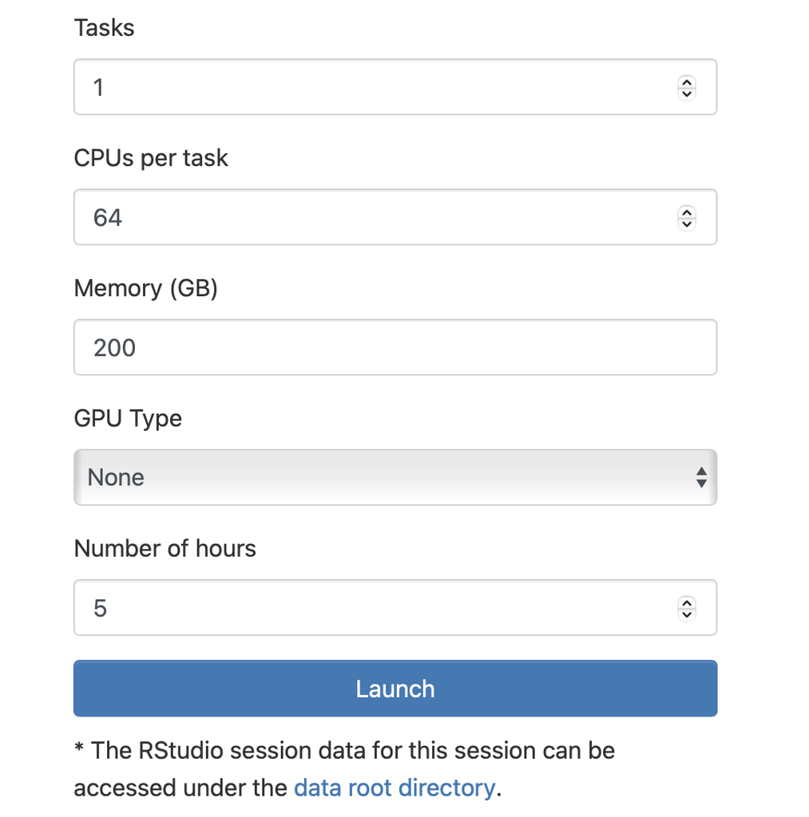

## Launch and Connect

The instance in Launched

[figure not shown]